# Discovering disproportionate jail rate of black people in the United States

Victor Ahn

02.25.2022

### Introduction

The United States is known for its *high incarceration rate* within the country. There have been unsolved problems and questions over the *disproportionate incarceration rate of people of color* compared to white people. This project will focus on **how the jail rate (People in jail /Population) varies between white people and black people in different regions** in the United States (South, West, Midwest) since the start of the 21st century.

### Summary Information

Values that I found relevant are *mean of total jail rates in three different regions*, mean of white jail rates in three different regions, mean of black jail rates in three different regions and mean of black jail rate over white jail rate in three different regions. First of all, it is **important** to use the jail rate instead of jail population because the total population varies among race groups. Absolute numbers cannot testify whether disproportionate incarceration is true. *Comparing relative percentages will be a right way to find out the existence of disproportion.* These values I chose are necessary because mean values are helpful to compare jail rates between white and black in different regions in the U.S during the 21st century. Mean value of black jail rate over white jail rate is also important because it demonstrates how many times more certain groups are incarcerated than the other.

**Here are the results and interpretations of my values:**

Mean of total population jail rate (South/West/Midwest): **0.29% / 0.1% / 0.13%** *(Average total jail rate during 2000 to 2018 is the highest in the South, then Midwest, and lowest in the West.)*

Mean of black jail rate (South/West/Midwest): **0.93% / 0.18% / 1.13 %** *(Average jail rate of black people during 2000 to 2018 is the highest in the Midwest, then South, and lowest in the West.)*

Mean of white jail rate (South/West/Midwest): **0.27% / 0.55% / 0.15%** *(Average jail rate of white people during 2000 to 2018 is the highest in the West, then in the South and lowest in the Midwest.)*

Mean of black jail rate over white jail rate (South/West/Midwest): **3.49 / 0.25 / 6.08** *(Average jail rate of black people is 3.49 times higher than that of white people in the South, 6.08 times higher in the Midwest. It is 0.25 times higher in the West which means the jail rate of white people is 4 times higher in the west than that of black people.)*

### Black Over White Jail Rate during 2000-2018 by Regions

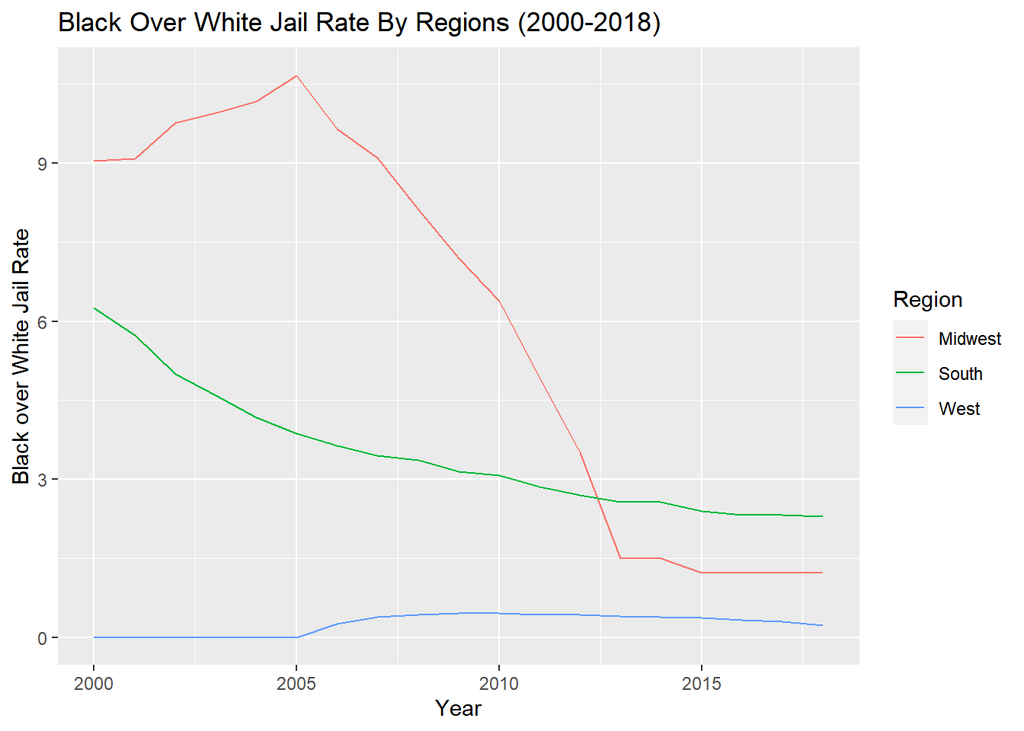

```r
ggp_total
```